# Generalized dose-escalation safety schematics via Dose Transition Pathways (DTP)

David C. Norris

1/12/2021

# Aims

Norris (2020b) proposed a universal schematic for evaluating the safety of the 3+3 dose-escalation design, and conjectured that the *dose transition pathways* (DTP) of Yap et al. (2017) would enable a similar treatment of model-based designs. This vignette explores that conjecture in relation to the continual reassessment method (CRM), using the `dtpcrm` package (Yap et al. 2019).

# Generalized exact simulation of dose escalation

Dose-escalation trial designs commonly operate with a fixed set of $D$ prespecified doses, enrolling participants in small cohorts of size $C$, at doses selected sequentially according to observed counts of binary dose-limiting toxicities (DLTs). Under such designs, the observations at any point in the trial may be recorded in a $C \times D$ matrix of toxicity counts $\{0, 1, ..., C, -\}$, with ‘$-$’ being used where a cohort has not been enrolled. Indeed, for deterministic designs in which dose-escalation decisions depend strictly on the history of observed DLT counts, such matrices suffice to account for the full dose-escalation sequence. For designs with upper bounds on enrollment, $C$ may be fixed *ex ante*, and all possible paths comprehensively enumerated.

To see this, consider that one may ‘read’ such a matrix, starting from the (deterministic) starting dose, and applying the (deterministic) design rules at each step. That is, a deterministic design *by definition* imposes a unique sequence on the entries in such a matrix.

In Norris (2020b), for example, paths through the 3+3 design could be represented as $2 \times D$ matrices because the 3+3 design enrolls at most 2 cohorts at any given dose. The mathematical treatment offered there for the path matrices $T_{c,d}^j$ was independent of the 3+3 rules, however, and carries forward generally:

Denoting the prespecified doses by $(X_d)$ and the cumulative distribution function of $\mathrm{MTD}_i$ by $P$, we can write the vector $(\pi^j)$ of path probabilities:

$$\begin{align}
p_d &= P(\mathrm{MTD}_i< X_d)\quad\mbox{(dose-wise toxicity probabilities)}\\
q_d &= 1 - p_d\\
\pi^j &= \prod_{c,d} {n \choose T_{c,d}^j} p_d^{T_{c,d}^j} q_d^{(n-T_{c,d}^j)}\quad\mbox{(path probabilities)} \tag{1}
\end{align}$$

Again as in Norris (2020b), taking logs in (1) we find:

$$\log \boldsymbol{\pi} = \sum_{c,d} \log {n \choose T_{c,d}} + \sum_c [T_{c,d},n-T_{c,d}]\left[{ \log \mathbf{p} \atop \log \mathbf{q}} \right] = \mathbf{b} + U\left[{ \log \mathbf{p} \atop \log \mathbf{q}} \right], \tag{2}$$
where the $J \times 2D$ matrix $U$ and the $J$-vector $\mathbf{b}$ are characteristic *constants* of the given dose-escalation design.

Finally, we may as previously introduce the log-therapeutic index $\kappa$, enabling us to write the fatal (grade-5) fraction $f_d$ of DLTs as:

$$f_d = \frac{P(e^{2\kappa} \mathrm{MTD}_i< X_d)}{P(\mathrm{MTD}_i< X_d)}, \tag{3}$$

in terms of which the expected number of fatal toxicities is:

$$\boldsymbol{\pi}^\intercal \mathrm{Y} \mathbf{f}, \tag{4}$$

where $Y = \sum_c T_{c,d}^j$ denotes the $(J \times D)$ left half of $U$.

# Connection with DTP

The DTP idea apparently was introduced primarily as a means to reconcile model-based formulations of dose-escalation trials with the habitually rule-based thinking of clinicians. Specifically, Yap et al. (2017) cites 3 specific “perceived challenges” in making the transition from rule-based to model-based designs:

1. The “flexibility” of model-based designs (which I take to mean the additional free parameters they introduce into the design space) creates choices which cannot readily be appreciated in the rule-based terms familiar to clinical investigators.
2. Benefits of model-based designs are likewise not apparent to clinical investigators, against the background of “rule-based designs perceived to be ‘successful’ for decades”.
3. From the trialist’s perspective, the ‘black-box’ recommendations of model-based designs “contrast unfavorably with the transparent, simple rules of a rule-based design.”

# An application

We will adopt the same parameters as in the `dtpcrm` [package vignette](https://cran.r-project.org/package=dtpcrm/vignettes/dtpcrm_vignettev02.html):

See Table 1 in Craddock et al. (2019).

## VIOLA set-up

### Clinical parameters

```r
number.doses <- 7
start.dose.level <- 3
max.sample.size <- 21
target.DLT <- 0.2
cohort.size <- 3
```

Note that the sample size limit allows us to set $C=7$.

### Model specification parameters

```r
prior.DLT <- c(0.03, 0.07, 0.12, 0.20, 0.30, 0.40, 0.52)
prior.var <- 0.75
```

### Early stopping

```r
stop_func <- function(x) {
  y <- stop_for_excess_toxicity_empiric(x,
                                        tox_lim = target.DLT + 0.1,
                                        prob_cert = 0.72,
                                        dose = 1,
                                        nsamps = 100000)
  if(y$stop){
    x <- y
  } else {
    x <- stop_for_consensus_reached(x, req_at_mtd = 12)
  }
}
```

## Computing DTPs

```r
t0 <- proc.time()
viola_dtp <- calculate_dtps(next_dose = start.dose.level,
                            cohort_sizes = rep(cohort.size, 7),
                            dose_func = applied_crm,
                            prior = prior.DLT,
                            target = target.DLT,
                            stop_func = stop_func,
                            scale = sqrt(prior.var),
                            no_skip_esc = TRUE,
                            no_skip_deesc = FALSE,
                            global_coherent_esc = TRUE
                            )
save(viola_dtp, file="../data/viola_dtp.rda")
proc.time() - t0 # ~17 minutes on a 2.6GHz i7
```

With each of (up to) 7 cohorts having 4 possible outcomes (0, 1, 2 or 3 toxicities), the DTP tabulation lists a total of $4^7 = 16384$ paths. These are not all distinct paths, however, since early stopping results in path degeneracy. For example, we can see that paths 1005–1008 all terminate at the 6th cohort, resulting in a $4\times$ degeneracy:

```r
knitr::kable(viola_dtp[1000:1010,])
```

|  | D0 | T1 | D1 | T2 | D2 | T3 | D3 | T4 | D4 | T5 | D5 | T6 | D6 | T7 | D7 |
| --- | --- | --- | --- | --- | --- | --- | --- | --- | --- | --- | --- | --- | --- | --- | --- |
| 1000 | 3 | 0 | 4 | 0 | 5 | 3 | 3 | 3 | 1 | 2 | 1 | 1 | 1 | 3 | NA |
| 1001 | 3 | 0 | 4 | 0 | 5 | 3 | 3 | 3 | 1 | 2 | 1 | 2 | 1 | 0 | 1 |
| 1002 | 3 | 0 | 4 | 0 | 5 | 3 | 3 | 3 | 1 | 2 | 1 | 2 | 1 | 1 | 1 |
| 1003 | 3 | 0 | 4 | 0 | 5 | 3 | 3 | 3 | 1 | 2 | 1 | 2 | 1 | 2 | NA |
| 1004 | 3 | 0 | 4 | 0 | 5 | 3 | 3 | 3 | 1 | 2 | 1 | 2 | 1 | 3 | NA |
| 1005 | 3 | 0 | 4 | 0 | 5 | 3 | 3 | 3 | 1 | 2 | 1 | 3 | NA | NA | NA |
| 1006 | 3 | 0 | 4 | 0 | 5 | 3 | 3 | 3 | 1 | 2 | 1 | 3 | NA | NA | NA |
| 1007 | 3 | 0 | 4 | 0 | 5 | 3 | 3 | 3 | 1 | 2 | 1 | 3 | NA | NA | NA |
| 1008 | 3 | 0 | 4 | 0 | 5 | 3 | 3 | 3 | 1 | 2 | 1 | 3 | NA | NA | NA |
| 1009 | 3 | 0 | 4 | 0 | 5 | 3 | 3 | 3 | 1 | 3 | 1 | 0 | 1 | 0 | 1 |
| 1010 | 3 | 0 | 4 | 0 | 5 | 3 | 3 | 3 | 1 | 3 | 1 | 0 | 1 | 1 | 1 |

Paths terminating at the 5th cohort would be listed 16 times, and those terminating at the 4th cohort 64 times, etc. The net degeneracy indeed proves to be quite substantial, inflating the DTP table by a factor of `3.5`:

```r
viola_paths <- as.matrix(unique(viola_dtp))
nrow(viola_paths)
```

```
## [1] 4689
```

To distinguish it from the degenerate DTP table returned by `dtpcrm::calculate_dtps`, we will refer to `viola_paths` as the DTP *matrix*.

# Computing $\mathbf{b}$ and $\mathrm{U}$ from the DTP matrix

## Transform DTP table into $T_{c,d}^j$

```r
I <- outer(viola_paths[,paste0("D",0:6)], 1:7, FUN = "==")
I[I] <- 1
I[!I] <- NA
# Now I[j,c,d] is an indicator array that we may use
# in the manner of a bitmask, to select the toxicities
# into their proper positions within T[j,c,d]:
T <- I * outer(viola_paths[,paste0("T",1:7)], rep(1,7))
dimnames(T)[[2]] <- paste0("C",1:7) # best labeled as Cohorts
dimnames(T)[[3]] <- paste0("X",1:7) # label as doses X1..X7
dim(T)
```

```
## [1] 4689    7    7
```

## Compute $\mathbf{b} = \sum_c {n \choose T_{c,d}}$

```r
b <- apply(log(choose(3, T)), MARGIN = 1, FUN = sum, na.rm = TRUE)
length(b)
```

```
## [1] 4689
```

## Compute $\mathrm{U}$ and $\mathrm{Y}$

```r
Y <- apply(T, MARGIN = c(1,3), FUN = sum, na.rm = TRUE)
Z <- apply(3-T, MARGIN = c(1,3), FUN = sum, na.rm = TRUE)
U <- cbind(Y, Z)
dim(U)
```

```
## [1] 4689   14
```

## Derive $\mathbf{\pi}$ from the CRM skeleton, to check that $\sum_j \pi^j \equiv 1$

```r
log_p <- log(prior.DLT)
log_q <- log(1 - prior.DLT)
log_pi <- b + U %*% c(log_p, log_q)
sum(exp(log_pi)) # check probabilities sum to 1
```

```
## [1] 1
```

# Fitting a lognormal $\mathrm{MTD}_i$ to VIOLA’s CRM skeleton

Whereas the analysis of Norris (2020b) was carried forth under a thoroughly logarithmic scaling of *dose*, the dosing intervals employed in the VIOLA trial are suggestive of an approximately square-root dose scaling—at least for the nonzero doses:

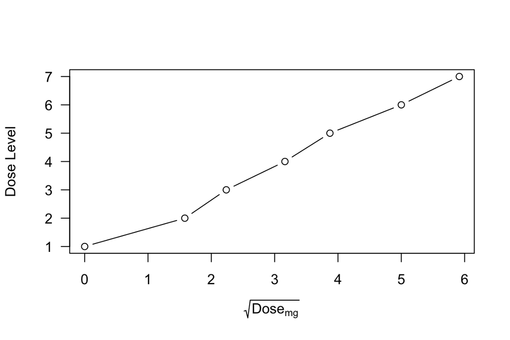

```r
viola_dosing <-
  data.frame(Label = -2:4 # VIOLA dose designations -2,...,4
            ,Level =  1:7  # We use integer dose indexes here
            ,Dose_mg = c(0, 2.5, 5, 10, 15, 25, 35)
            ,skeleton = prior.DLT
             )
viola_dosing <- viola_dosing %>%
  mutate(log_dose = log(Dose_mg)
        ,sqrt_dose = sqrt(Dose_mg)
        )

plot(Level ~ sqrt_dose, data = viola_dosing, type = 'b'
     , ylab = "Dose Level"
     , xlab = expression(sqrt(Dose[mg]))
     , las = 1
     )
```

Indeed, the CRM skeleton looks quite close to a normal distribution under this scaling:

Figure 1: CRM skeleton probabilities vs $\sqrt{\mathrm{Dose}}$, with superimposed normal distribution having median $\sqrt{33}$ and standard deviation 3.

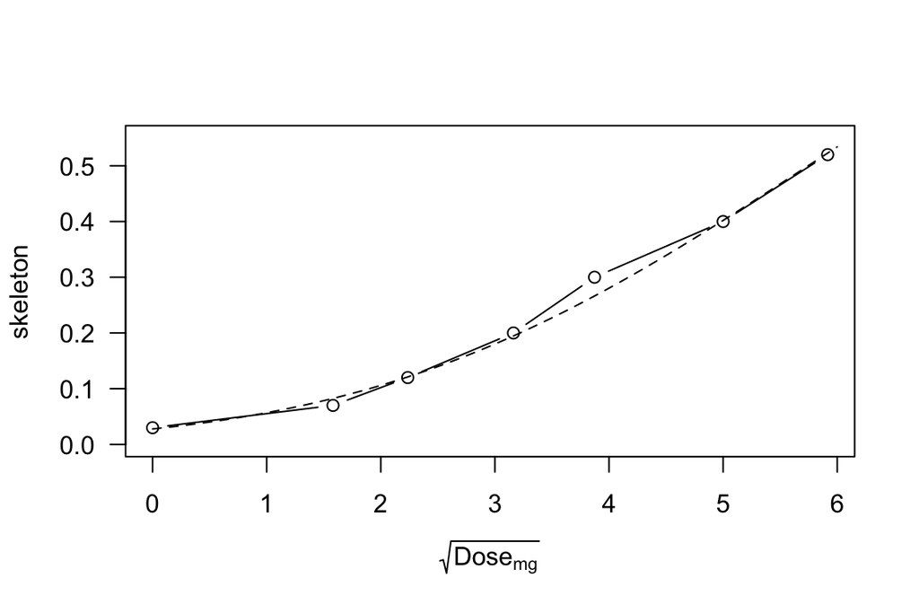

```r
plot(skeleton ~ sqrt_dose, data = viola_dosing
     , type = 'b'
     , xlab = expression(sqrt(Dose[mg]))
     , ylim = c(0, 0.55)
     , las = 1)
x <- seq(0, 6, 0.1)
y <- pnorm(x, mean = sqrt(33), sd = 3)
lines(y ~ x, lty = 2)
```

Nevertheless, the treatment of zero dose under this scaling is pharmacologically problematic, if not outright homeopathic, so we will proceed instead using a lognormal $\mathrm{MTD}_i$ distribution fitted to the CRM skeleton.

Figure 2: CRM skeleton probabilities vs $\log \mathrm{Dose}$, with superimposed lognormal distribution having median $\mu = 35$mg and $\sigma = 1.6$.

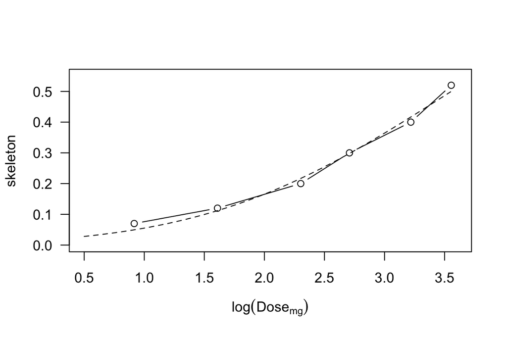

```r
plot(skeleton ~ log_dose, data = subset(viola_dosing, is.finite(log_dose))
     , type = 'b'
     , xlab = expression(log(Dose[mg]))
     , xlim = c(0.5, 3.6)
     , ylim = c(0, 0.55)
     , las = 1)

sse <- function(mu_sigma, dose = viola_dosing$Dose_mg){
  mu <- mu_sigma[1]
  sigma <- mu_sigma[2]
  lnorm.DLT <- plnorm(dose, meanlog = mu, sdlog = sigma)
  sse <- sum((lnorm.DLT - prior.DLT)[dose > 0]^2)
}
fit <- optim(par = c(mu=log(38), sigma=1.8), fn = sse)
mu_opt <- log(round(exp(fit$par['mu']), 1))
sigma_opt <- round(fit$par['sigma'], 1)
x <- seq(0.5, 3.55, 0.05)
y <- plnorm(exp(x), meanlog = mu_opt, sdlog = sigma_opt)
lines(y ~ x, lty = 2)
```

# VIOLA safety

Taking this CRM skeleton fit as a modal expectation of the $\mathrm{MTD}_i$ distribution, we may employ Equations (3)–(4) to obtain an expected number of fatal toxicities, as a function of $\kappa$:

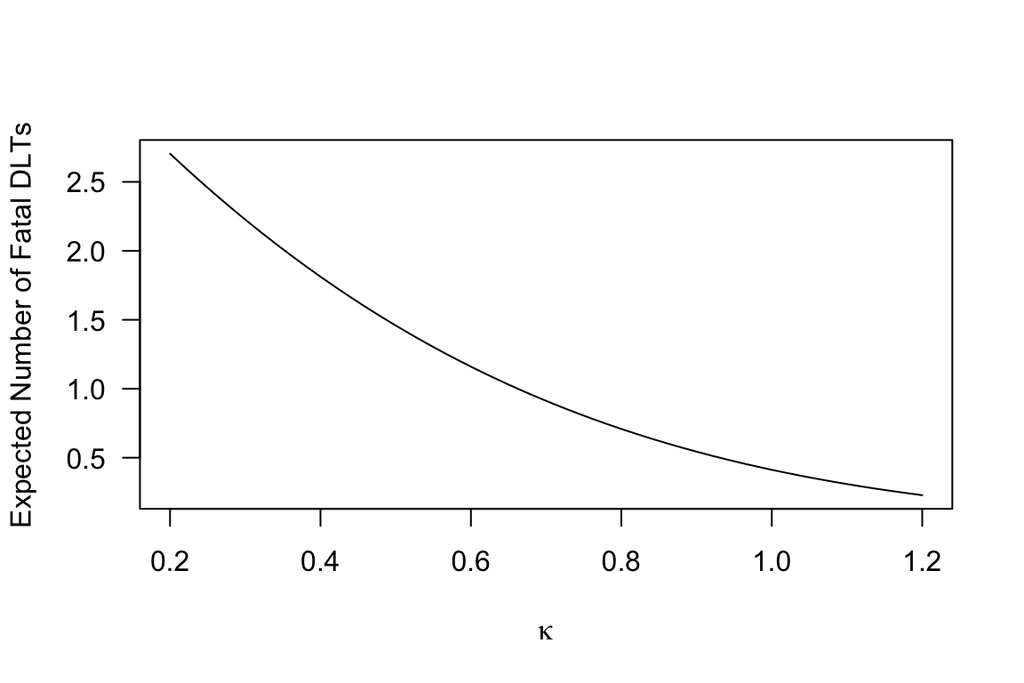

```r
f <- function(kappa, mu=mu_opt, sigma=sigma_opt, X=viola_dosing$Dose_mg) {
  # For ease of use, this function is VECTORIZED over kappa,
  # generally returning a length(X) x length(kappa) MATRIX
  # which can validly right-multiply Y in t(pi) %*% Y %*% f.
  # (In the special case length(kappa)==1, a vector is returned.)
  gr5 <- plnorm(outer(X, exp(-2*kappa)), meanlog = mu, sdlog = sigma)
  dlt <- plnorm(outer(X, exp( 0*kappa)), meanlog = mu, sdlog = sigma)
  ff <- gr5/dlt
  ff[is.nan(ff)] <- 0 # replace NaN caused by X[1]==0
  dimnames(ff) <- list(
    dose = paste0("X", seq_along(X)),
    kappa = round(kappa, 3)
  )
  if (length(kappa)==1)
    return(as.vector(ff))
  ff
}

kappa <- seq(0.2, 1.2, 0.02)
F <- f(kappa = kappa)
Ef <- t(exp(log_pi)) %*% Y %*% F
Ef <- t(Ef) # transpose to a column-vector
plot(Ef ~ kappa, type = 'l'
     , xlab = expression(kappa)
     , ylab = "Expected Number of Fatal DLTs"
     , las=1)
```